# hw1_revised

```python
# For data loading and scientific computing
import pandas as pd
import numpy as np
import random
import os
import csv

# For data visualization
import matplotlib.pyplot as plt
import plotly.express as px

# Deep learning framework
import torch
import torch.nn as nn

# data processing and evaluation
from sklearn.model_selection import train_test_split
from sklearn.metrics import accuracy_score, f1_score

import warnings
warnings.filterwarnings('ignore')
```

## Configuration

- `config`：集中管理參數的類別，方便調整超參數與環境參數訓練設定。
- `batch_size`：一次訓練時送入模型的資料筆數，值越大，訓練更穩定但吃更多記憶體；越小則更新較快但較 noisy。
- `learning rate`：控制模型更新參數的步伐，太大會跳來跳去，太小會收斂太慢。
- `epoch`：每個 epoch 是完整掃過一次訓練資料。
- `weight_decay`：正則化強度，權重值太大會被罰，幫助模型不要學得太複雜跟 overfitting。

```python
class config:
    root = "/Users/tintsao/Desktop/交大統研所/碩一上/深度學習/DL_hw/Hw1/dataset"
    batch_size = 16
    lr = 1e-3
    epochs = 40
    weight_decay = 0.003  #對loss funtion的懲罰項，模型越複雜，loss會越大，有防止overfitting的用意。
    device = torch.device("cuda" if torch.cuda.is_available() else "cpu")
    seed = 66
```

## Utils

```python
def seed_everything(seed):
    # Set Python random seed
    random.seed(seed)

    # Set NumPy random seed
    np.random.seed(seed)

    # Set PyTorch random seed for CPU and GPU
    torch.manual_seed(seed)
    if torch.cuda.is_available():
        torch.cuda.manual_seed_all(seed)

    # Set PyTorch deterministic operations for cudnn backend
    torch.backends.cudnn.deterministic = True  #True:相同輸入、相同模型、相同權重 每次都輸出一樣結果（可重現）
    torch.backends.cudnn.benchmark = False     #True:自動尋找最佳算法，提升運算效率，但為了重現性我們設成 False 。
```

## EDA

```python
# Read in the dataframe
train_path = os.path.join(config.root, 'train.csv')
test_path = os.path.join(config.root, 'test.csv')

train_data = pd.read_csv(train_path, header=None)
test_data = pd.read_csv(test_path, header=None)

train_data.head(3)
```

|  | 0 | 1 | 2 | 3 | 4 | 5 | 6 | 7 | 8 | 9 | ... | 248 | 249 | 250 | 251 | 252 | 253 | 254 | 255 | 256 | 257 |
| --- | --- | --- | --- | --- | --- | --- | --- | --- | --- | --- | --- | --- | --- | --- | --- | --- | --- | --- | --- | --- | --- |
| 0 | A1 | 6 | -1.0 | -1.0 | -1.0 | -1.000 | -1.000 | -1.000 | -1.000 | -0.631 | ... | 0.304 | 0.823 | 1.000 | 0.482 | -0.474 | -0.991 | -1.000 | -1.000 | -1.000 | -1.0 |
| 1 | A2 | 5 | -1.0 | -1.0 | -1.0 | -0.813 | -0.671 | -0.809 | -0.887 | -0.671 | ... | -0.671 | -0.671 | -0.033 | 0.761 | 0.762 | 0.126 | -0.095 | -0.671 | -0.828 | -1.0 |
| 2 | A3 | 4 | -1.0 | -1.0 | -1.0 | -1.000 | -1.000 | -1.000 | -1.000 | -1.000 | ... | -1.000 | -1.000 | -1.000 | -0.109 | 1.000 | -0.179 | -1.000 | -1.000 | -1.000 | -1.0 |

3 rows × 258 columns

```python
train_data.iloc[:, 2:].describe() #總結資料集分佈的集中趨勢、離散度和形狀（不包括 NaN值）
```

|  | 2 | 3 | 4 | 5 | 6 | 7 | 8 | 9 | 10 | 11 | ... | 248 | 249 | 250 | 251 | 252 | 253 | 254 | 255 | 256 | 257 |
| --- | --- | --- | --- | --- | --- | --- | --- | --- | --- | --- | --- | --- | --- | --- | --- | --- | --- | --- | --- | --- | --- |
| count | 7291.000000 | 7291.000000 | 7291.000000 | 7291.000000 | 7291.000000 | 7291.000000 | 7291.000000 | 7291.000000 | 7291.000000 | 7291.000000 | ... | 7291.000000 | 7291.000000 | 7291.000000 | 7291.000000 | 7291.000000 | 7291.000000 | 7291.000000 | 7291.000000 | 7291.000000 | 7291.000000 |
| mean | -0.996417 | -0.981138 | -0.951153 | -0.887738 | -0.773468 | -0.610302 | -0.368991 | -0.045769 | -0.052641 | -0.284564 | ... | -0.198547 | 0.139823 | 0.116439 | -0.314108 | -0.653711 | -0.837858 | -0.922194 | -0.957393 | -0.979290 | -0.994678 |
| std | 0.051713 | 0.151202 | 0.244264 | 0.360516 | 0.502659 | 0.628710 | 0.716032 | 0.768304 | 0.752979 | 0.746838 | ... | 0.772895 | 0.752984 | 0.757336 | 0.725859 | 0.582555 | 0.414646 | 0.300830 | 0.228700 | 0.158998 | 0.066056 |
| min | -1.000000 | -1.000000 | -1.000000 | -1.000000 | -1.000000 | -1.000000 | -1.000000 | -1.000000 | -1.000000 | -1.000000 | ... | -1.000000 | -1.000000 | -1.000000 | -1.000000 | -1.000000 | -1.000000 | -1.000000 | -1.000000 | -1.000000 | -1.000000 |
| 25% | -1.000000 | -1.000000 | -1.000000 | -1.000000 | -1.000000 | -1.000000 | -1.000000 | -0.999000 | -0.950000 | -1.000000 | ... | -1.000000 | -0.661500 | -0.738000 | -1.000000 | -1.000000 | -1.000000 | -1.000000 | -1.000000 | -1.000000 | -1.000000 |
| 50% | -1.000000 | -1.000000 | -1.000000 | -1.000000 | -1.000000 | -1.000000 | -0.719000 | 0.061000 | 0.002000 | -0.561000 | ... | -0.353000 | 0.368000 | 0.336000 | -0.579000 | -1.000000 | -1.000000 | -1.000000 | -1.000000 | -1.000000 | -1.000000 |
| 75% | -1.000000 | -1.000000 | -1.000000 | -1.000000 | -0.962000 | -0.391000 | 0.254500 | 0.696000 | 0.674500 | 0.438000 | ... | 0.554000 | 0.835000 | 0.815000 | 0.346000 | -0.504500 | -1.000000 | -1.000000 | -1.000000 | -1.000000 | -1.000000 |
| max | 0.638000 | 1.000000 | 1.000000 | 1.000000 | 1.000000 | 1.000000 | 1.000000 | 1.000000 | 1.000000 | 1.000000 | ... | 1.000000 | 1.000000 | 1.000000 | 1.000000 | 1.000000 | 1.000000 | 1.000000 | 1.000000 | 1.000000 | 0.592000 |

8 rows × 256 columns

```python
print(f"Number of training samples: {train_data.shape[0]}")
print(f"Number of testing samples: {test_data.shape[0]}")
```

```
Number of training samples: 7291
Number of testing samples: 2007
```

```python
#計算 train_data 標籤數量
train_data.iloc[:, 1].value_counts().sort_index()
```

```
1
0    1194
1    1005
2     731
3     658
4     652
5     556
6     664
7     645
8     542
9     644
Name: count, dtype: int64
```

## Show the number of images in each digit for the training dataset

首先取出 label 並計算每個出現的次數，接下來 label 的值由小到大排序。  
接著用 Bar Chart 把它畫出來。

```python
train_label_distribution = train_data.iloc[:, 1].value_counts().sort_index()
train_label_distribution = pd.DataFrame(
    {
        "labels": train_label_distribution.index.astype(str), #將int64改成str
        "number_of_samples": train_label_distribution.values
    }
)
# print(train_label_distribution)

#以下兩個是視覺化參數設定
fig = px.bar(
    train_label_distribution, x="labels", y="number_of_samples",
    labels=dict(y="number of samples"),
)
# update_layout 用來更新圖表的佈局配置，調整圖表的外觀和樣式
fig.update_layout(
    plot_bgcolor='white',
    xaxis=dict(showgrid=True, gridcolor='lightgray', zeroline=False),  # Show x-axis grid，zeroline=False為不顯示x=0那條線
    yaxis=dict(showgrid=True, gridcolor='lightgray', zeroline=False),  # Show y-axis grid，zeroline=False為不顯示y=0那條線
    title=dict(text="Number of Samples Per Labels", x=0.5, y=0.975, font=dict(size=20))
)
fig.show()
```

[output not shown]

## Pytorch Dataset

pytorch dataset 必須為自定義物件，且須繼承於 `torch.utils.data.Dataset`。我們必須實現下列方法

- `__init__:` Initialization Setting
- `__len__:` return the length of the data
- `__getitem__:` return the data according to the index draw from sampler

Pandas 的 DataFrame 這種資料結構適合處理表格，但不適合用在DL當中，因為他不支援 GPU 運算跟自動微分的功能

所以，我們要轉成 torch.tensor ，專門為DL所設計的框架，支援上述所提及的功能。

但 Pandas 和 PyTorch 會有兼容性問題，有些複雜的資料結構會出意外，在這種情況下，我們會先轉成NumPy來確保相容。

```python
class HandwrittenDigits(torch.utils.data.Dataset):
    def __init__(self, df, mode=None, transforms=None):
        self.df = df
        self.transforms = transforms
        self.mode = mode

    def __len__(self):
        return len(self.df)

    def __getitem__(self, x):
        if self.mode == "train":
            ID = self.df.iloc[x, 0]                                 #抓取第 x 筆資料，第 0 欄為 image_id。
            label = self.df.iloc[x, 1]                              #抓取第 x 筆資料，第 1 欄為 image_label。
            image = self.df.iloc[x, 2:].to_numpy(dtype=np.float32)  #抓取第 x 筆資料，第 2 欄為 image 的 pixel。

            if self.transforms:
                image = image.reshape(16, 16)                    # 還原成影像格式
                transformed = self.transforms(image=image)
                image = transformed["image"].view(-1)            # 攤平成 (256,) 給 MLP 用

            else:
                image = torch.tensor(image).view(-1)             # 沒 transform 時手動轉 tensor
                label = torch.tensor(label)                          # label 轉成 tensor（int）

            # label, image = torch.tensor(label), torch.tensor(image)

            # if self.transforms: #這個只會用在 train_data 身上，所以 valid_data 不用。
            #     transformed = self.transforms(image=image)
            #     image = transformed['image']

            return ID, label, image

        elif self.mode == "valid":
            ID = self.df.iloc[x, 0]                                 #抓取第 x 筆資料，第 0 欄為 image_id。
            label = self.df.iloc[x, 1]                              #抓取第 x 筆資料，第 1 欄為 image_label。
            image = self.df.iloc[x, 2:].to_numpy(dtype=np.float32)  #抓取第 x 筆資料，第 2 欄為 image 的 pixel。
            label, image = torch.tensor(label), torch.tensor(image)

            return ID, label, image

        elif self.mode == "test":
            ID = self.df.iloc[x, 0]
            image = self.df.iloc[x, 1:].to_numpy(dtype=np.float32)
            image = torch.tensor(image)

            return ID, image  # 因為 test 沒 label
```

## Transform

```python
import albumentations as A
from albumentations.pytorch import ToTensorV2

transform = A.Compose([
    # A.GaussNoise(var_limit=(5.0, 10.0), p=0.3),  # 隨機加高斯雜訊 效果 bad
    A.Rotate(limit=15, p=0.3),  # 隨機旋轉 -10°～10°
    ToTensorV2()
])
```

```python
ds = HandwrittenDigits(train_data, mode = "train", transforms = transform)
ds[0]
```

```
('A1',
 np.int64(6),
 tensor([-1.0000, -1.0000, -1.0000, -1.0000, -1.0000, -1.0000, -1.0000, -0.6310,
          0.8620, -0.1670, -1.0000, -1.0000, -1.0000, -1.0000, -1.0000, -1.0000,
         -1.0000, -1.0000, -1.0000, -1.0000, -1.0000, -1.0000, -0.9920,  0.2970,
          1.0000,  0.3070, -1.0000, -1.0000, -1.0000, -1.0000, -1.0000, -1.0000,
         -1.0000, -1.0000, -1.0000, -1.0000, -1.0000, -1.0000, -0.4100,  1.0000,
          0.9860, -0.5650, -1.0000, -1.0000, -1.0000, -1.0000, -1.0000, -1.0000,
         -1.0000, -1.0000, -1.0000, -1.0000, -1.0000, -0.6830,  0.8250,  1.0000,
          0.5620, -1.0000, -1.0000, -1.0000, -1.0000, -1.0000, -1.0000, -1.0000,
         -1.0000, -1.0000, -1.0000, -1.0000, -0.9380,  0.5400,  1.0000,  0.7780,
         -0.7150, -1.0000, -1.0000, -1.0000, -1.0000, -1.0000, -1.0000, -1.0000,
         -1.0000, -1.0000, -1.0000, -1.0000,  0.1000,  1.0000,  0.9220, -0.4390,
         -1.0000, -1.0000, -1.0000, -1.0000, -1.0000, -1.0000, -1.0000, -1.0000,
         -1.0000, -1.0000, -1.0000, -0.2570,  0.9500,  1.0000, -0.1620, -1.0000,
         -1.0000, -1.0000, -0.9870, -0.7140, -0.8320, -1.0000, -1.0000, -1.0000,
         -1.0000, -1.0000, -0.7970,  0.9090,  1.0000,  0.3000, -0.9610, -1.0000,
         -1.0000, -0.5500,  0.4850,  0.9960,  0.8670,  0.0920, -1.0000, -1.0000,
         -1.0000, -1.0000,  0.2780,  1.0000,  0.8770, -0.8240, -1.0000, -0.9050,
          0.1450,  0.9770,  1.0000,  1.0000,  1.0000,  0.9900, -0.7450, -1.0000,
         -1.0000, -0.9500,  0.8470,  1.0000,  0.3270, -1.0000, -1.0000,  0.3550,
          1.0000,  0.6550, -0.1090, -0.1850,  1.0000,  0.9880, -0.7230, -1.0000,
         -1.0000, -0.6300,  1.0000,  1.0000,  0.0680, -0.9250,  0.1130,  0.9600,
          0.3080, -0.8840, -1.0000, -0.0750,  1.0000,  0.6410, -0.9950, -1.0000,
         -1.0000, -0.6770,  1.0000,  1.0000,  0.7530,  0.3410,  1.0000,  0.7070,
         -0.9420, -1.0000, -1.0000,  0.5450,  1.0000,  0.0270, -1.0000, -1.0000,
         -1.0000, -0.9030,  0.7920,  1.0000,  1.0000,  1.0000,  1.0000,  0.5360,
          0.1840,  0.8120,  0.8370,  0.9780,  0.8640, -0.6300, -1.0000, -1.0000,
         -1.0000, -1.0000, -0.4520,  0.8280,  1.0000,  1.0000,  1.0000,  1.0000,
          1.0000,  1.0000,  1.0000,  1.0000,  0.1350, -1.0000, -1.0000, -1.0000,
         -1.0000, -1.0000, -1.0000, -0.4830,  0.8130,  1.0000,  1.0000,  1.0000,
          1.0000,  1.0000,  1.0000,  0.2190, -0.9430, -1.0000, -1.0000, -1.0000,
         -1.0000, -1.0000, -1.0000, -1.0000, -0.9740, -0.4290,  0.3040,  0.8230,
          1.0000,  0.4820, -0.4740, -0.9910, -1.0000, -1.0000, -1.0000, -1.0000]))
```

## Pytorch DataLoader

怎麼讓neural network 批次(batch)讀取影像資料呢? 我們可以透過 pytorch dataloader 來達成，pytorch dataloader 包含三個部分

- sampler: 抽樣方式，主要是生出一組index。

  常見的抽樣方式包括：

  SequentialSampler: 順序抽樣，按照順序抽取資料。

  RandomSampler: 隨機抽樣，隨機抽取資料。

  SubsetRandomSampler: 從一個subset隨機抽樣。
- dataset: 對影像的處理方法，根據這組index提取相對應的資料。

  我們有自定義HandwrittenDigits，__getitem()__定義了如何讀取 image 與 label 。
- collate_fn: 對一個batch進行整合。

  Batch 是指在一次迭代（iteration）中， model 處理的資料樣本的數量。

  例如，1000個樣本，我可以設定每次迭代中使用 batch=32 (每次訓練都用32個樣本)。

  使用 Batch 可以在訓練過程中讓 gradient descent 更穩定、更平滑的更新，對於大型資料集可以避免一次性加載所有數據導致內存不足。

具體流程如下: sampler --> indices --> dataset --> collate_fn

視覺化詳見 https://twitter.com/_ScottCondron/status/1363494433715552259

```python
train_data = pd.read_csv(train_path, header=None)
train_dataset = HandwrittenDigits(train_data, mode = "train")
train_loader = torch.utils.data.DataLoader(train_dataset, batch_size=config.batch_size, shuffle=True) #shuffle=True代表使用 RandomSampler。
```

## For each digit, plot 10 randomly selected images from your training dataset.

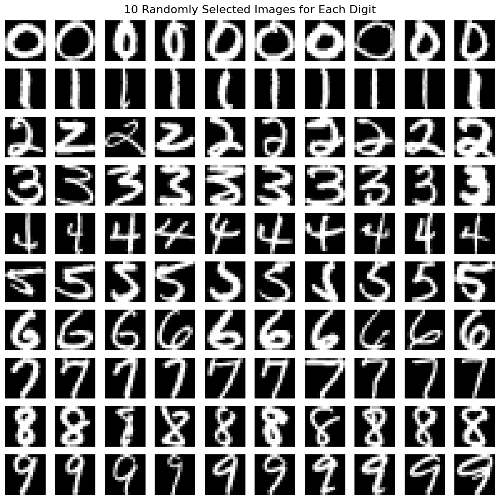

```python
# 建立字典用來儲存 0~9 的圖像
digit_images = {i: [] for i in range(10)}
# print(digit_images)

# 從train_dataset抓取 label 跟 image，並將 image 重塑成 16x16，放進字典中。
for ID, label, image in train_dataset:
    digit_images[label.item()].append(image.numpy().reshape(16, 16))

# 繪製每個數字的隨機10張圖片
fig, axes = plt.subplots(10, 10, figsize=(10, 10))
fig.suptitle('10 Randomly Selected Images for Each Digit', fontsize=16)

for digit in range(10):
    # 隨機選擇10張圖片
    selected_images = random.sample(digit_images[digit], 10)
    for i, img in enumerate(selected_images):
        ax = axes[digit, i]                                   #axes 是一個 10x10 的 matplotlib 子圖
        ax.imshow(img, cmap='gray')
        ax.axis('off')

plt.tight_layout() #自動調整圖片間距，避免圖像太過緊密。
plt.show()
```

# Pytorch Module

Pytorch neural network 同樣也是需自定義的物件，我們必須實現兩種方法

- `__init__:` model 的初始化函數，用於定義模型的結構
- `forward:` 定義了 model 向前傳播的過程

### 簡單前饋神經網路

用來處理分類或回歸任務。屬於典型的 多層感知器（MLP, Multi-Layer Perceptron） 結構。

```python
class SimpleNN(nn.Module):
    def __init__(self, input_dim, output_dim):
        super(SimpleNN, self).__init__()
        self.fc1 = nn.Linear(input_dim, 128)
        self.bn1 = nn.BatchNorm1d(128)
        self.relu1 = nn.ReLU()
        self.dropout1 = nn.Dropout(0.2)

        self.fc2 = nn.Linear(128, 64)
        self.bn2 = nn.BatchNorm1d(64)
        self.relu2 = nn.ReLU()
        self.dropout2 = nn.Dropout(0.2)

        self.final_fc = nn.Linear(64, output_dim)

    def forward(self, x):
        x = self.dropout1(self.relu1(self.bn1(self.fc1(x))))
        x = self.dropout2(self.relu2(self.bn2(self.fc2(x))))
        x = self.final_fc(x)
        return x
```

```python
input_dim =  256 # image 的 pixel 有 256
output_dim = 10  # 我們想要分類 0~9 其中一個類別

model = SimpleNN(input_dim, output_dim)
model
```

```
SimpleNN(
  (fc1): Linear(in_features=256, out_features=128, bias=True)
  (bn1): BatchNorm1d(128, eps=1e-05, momentum=0.1, affine=True, track_running_stats=True)
  (relu1): ReLU()
  (dropout1): Dropout(p=0.2, inplace=False)
  (fc2): Linear(in_features=128, out_features=64, bias=True)
  (bn2): BatchNorm1d(64, eps=1e-05, momentum=0.1, affine=True, track_running_stats=True)
  (relu2): ReLU()
  (dropout2): Dropout(p=0.2, inplace=False)
  (final_fc): Linear(in_features=64, out_features=10, bias=True)
)
```

## Evaluator

- `preds`: 模型預測的結果（通常是分類標籤）
- `gts`: ground truth，真實標籤（ground truths）

```python
def evaluator(preds, gts):
    preds = preds.cpu().numpy() if isinstance(preds, torch.Tensor) else preds # 將 Tensor 轉成 numpy ，如果是 Tensor 的話
    gts = gts.cpu().numpy() if isinstance(gts, torch.Tensor) else gts

    acc = accuracy_score(preds, gts)             # 計算正確率
    f1 = f1_score(preds, gts, average="macro")   # F1 score，介在 0~1 ，對 model 分類性能的綜合評價，越高越好
    misclassification_rate = 1 - acc             # 計算分錯率

    return acc, f1, misclassification_rate
```

## Training

```python
def train_one_epoch(model, train_loader, optimizer, scheduler, criterion, device):
    model.train()                                            # PyTorch 中一個用來告知 model 進行訓練的狀態設置，會啟用一些用在訓練的層（如 dropout 和 batch normalization）
    train_loss = .0                                          # 累積一個 epoch 的總損失
    predictions, ground_truths = [], []                      # 儲存所有的預測結果和對應的真實標籤。
    for ID, labels, images in train_loader:
        labels = labels.to(device=device, dtype=torch.long)  # nn.CrossEntropyLoss 要求 label 必須是長整數型態，一般的 int 不行。
        images = images.to(device=device, dtype=torch.float) # 將 image 移動到指定的設備（例如 GPU）上，並確保其資料型態為 float。

        optimizer.zero_grad()                                # 清空 optimizer 的梯度，避免梯度累加
        logits = model(images)                               # 將 image 輸入 model ，計算輸出的 logits。
        loss = criterion(logits, labels)                     # 計算 model 輸出與真實標籤之間的損失（loss）
        loss.backward()                                      # 計算 loss 對 model 參數的梯度

        optimizer.step()                                     # 更新 model 參數

        train_loss += loss.item()                            # 將當前 batch 的損失累加到總損失中。
        preds = torch.argmax(logits, dim=1)                  # 獲取機率最大的類別，當作預測

        predictions.append(preds)                            # 新增預測結果
        ground_truths.append(labels)                         # 新增真實標籤

    # scheduler.step()                                         # 更新 lr 的參數

    train_loss /= len(train_loader)                          # 計算整個 epoch 的平均損失

    predictions = torch.cat(predictions)                     # 將所有 batch 的預測結果拼成一個完整的張量。
    ground_truths = torch.cat(ground_truths)                 # 將所有的真實標籤拼成一個完整的張量。

    train_acc, train_f1, train_misclass = evaluator(predictions, ground_truths) # 計算當前 epoch 的 acc 、 F1 score 和 misclassification_rate

    return train_loss, 100*train_acc, 100*train_f1, 100*train_misclass
```

## Validation

```python
def validation(model, valid_loader, criterion, device, scheduler):
    model.eval()
    valid_loss = .0
    predictions, ground_truths = [], []
    with torch.no_grad(): # 不計算梯度
        for ID, labels, images in valid_loader:
            labels = labels.to(device=device, dtype=torch.long)
            images = images.to(device=device, dtype=torch.float)

            # validation 不需要計算梯度，所以不用 optimizer 、 loss.backward() 、 scheduler
            logits = model(images)  # dimension = out_dim = 10
            loss = criterion(logits, labels)

            valid_loss += loss.item()
            preds = torch.argmax(logits, dim=1)

            predictions.append(preds)
            ground_truths.append(labels)


    valid_loss /= len(valid_loader)

    predictions = torch.cat(predictions)
    ground_truths = torch.cat(ground_truths)

    valid_acc, valid_f1, valid_misclass = evaluator(predictions, ground_truths)

    return valid_loss, 100*valid_acc, 100*valid_f1, 100*valid_misclass
```

```python
def Run():

    seed_everything(config.seed)
    device = config.device

    train_data = pd.read_csv(os.path.join(config.root, 'train.csv'), header=None)

    # Split the training dataset in a 80: 20
    train_dataset, val_dataset = train_test_split(train_data, train_size=0.8, test_size=0.2, random_state=config.seed)

    train_dataset = HandwrittenDigits(train_dataset, mode = "train", transforms = transform)
    val_dataset = HandwrittenDigits(val_dataset, mode = "valid")

    train_loader = torch.utils.data.DataLoader(train_dataset, batch_size=config.batch_size, shuffle=True)  # 打亂資料順序可避免模型「記住順序」
    val_loader = torch.utils.data.DataLoader(val_dataset, batch_size=config.batch_size, shuffle=False)  # 每次驗證都一致、可重現

    criterion = nn.CrossEntropyLoss()

    model =  SimpleNN(input_dim=256, output_dim=10)
    model.to(device)

    parameters = [p for p in model.parameters() if p.requires_grad]  # 對 model 的所有參數，抓取那些需要計算梯度的參數用於更新
    optimizer = torch.optim.AdamW(parameters, lr=config.lr, weight_decay=config.weight_decay)
    # scheduler = torch.optim.lr_scheduler.StepLR(optimizer, step_size = 12, gamma = 0.1)  # 每訓練 12 個 epoch，就把學習率乘上 0.1
    scheduler = torch.optim.lr_scheduler.ReduceLROnPlateau(optimizer=optimizer,
        mode='min',              # 觀察的指標越小越好（通常是 val loss）
        factor=0.5,              # 每次下降乘上 0.5
        patience=3,              # 若連續 3 次都沒進步才降 lr
        verbose=True             # 顯示訊息
    )

    best_val_loss = float("inf")  # 初始設為「無限大」，之後只要有 val loss 更小就會更新這個值
    history = {
        "train": {
            "loss": [],
            "acc": [],
            "f1": [],
            "misclass": []
        },
        "valid": {
            "loss": [],
            "acc": [],
            "f1": [],
            "misclass": []
        },
    }

    for epoch in range(config.epochs):
        train_loss, train_acc, train_f1, train_misclass = train_one_epoch(model, train_loader, optimizer, scheduler, criterion, device)
        valid_loss, valid_acc, valid_f1, valid_misclass = validation(model, val_loader, criterion, device, scheduler)
        scheduler.step(valid_loss)

        # # 記錄訓練、驗證階段的指標
        history["train"]["loss"].append(train_loss)
        history["train"]["acc"].append(train_acc)
        history["train"]["f1"].append(train_f1)
        history["train"]["misclass"].append(train_misclass)
        history["valid"]["loss"].append(valid_loss)
        history["valid"]["acc"].append(valid_acc)
        history["valid"]["f1"].append(valid_f1)
        history["valid"]["misclass"].append(valid_misclass)

        print(f'Epoch[{epoch+1}/{config.epochs}], Train Loss: {train_loss:.4f}, Train Acc: {train_acc:.2f}%, Train F1: {train_f1:.2f}% | Valid Loss: {valid_loss:.4f}, Valid Acc: {valid_acc:.2f}%, Valid F1: {valid_f1:.2f}%, Valid Misclass: {valid_misclass:.2f}% | LR: {optimizer.state_dict()["param_groups"][0]["lr"]:.6f}')

        if valid_loss < best_val_loss:
            save_file = {
                "model": model.state_dict(),
                "optimizer": optimizer.state_dict(),
                "scheduler": scheduler.state_dict(),
                "epoch": epoch,
                "args": config
            }
            best_val_loss = valid_loss
            torch.save(save_file, "checkpoint.pth")

    plt.figure(figsize=(12, 5))
    plt.subplot(1, 2, 1)
    plt.plot(range(config.epochs), history["train"]["loss"], label='Training Loss')
    plt.plot(range(config.epochs), history["valid"]["loss"], label='Validation Loss')
    plt.xlabel('Epoch')
    plt.ylabel('Loss')
    plt.legend()
    plt.title('Training and Validation Loss Curves')
    plt.show()

    plt.figure(figsize=(12, 5))
    plt.subplot(1, 2, 1)
    plt.plot(range(config.epochs), history["train"]["acc"], label='Training Acc')
    plt.plot(range(config.epochs), history["valid"]["acc"], label='Validation Acc')
    plt.xlabel('Epoch')
    plt.ylabel('Acc')
    plt.legend()
    plt.title('Training and Validation Accuracy Curves')
    plt.show()

    plt.figure(figsize=(12, 5))
    plt.subplot(1, 2, 1)
    plt.plot(range(config.epochs), history["train"]["f1"], label='Training F1')
    plt.plot(range(config.epochs), history["valid"]["f1"], label='Validation F1')
    plt.xlabel('Epoch')
    plt.ylabel('F1')
    plt.legend()
    plt.title('Training and Validation F1 Score Curves')
    plt.show()

    plt.figure(figsize=(12, 5))
    plt.subplot(1, 2, 1)
    plt.plot(range(config.epochs), history["train"]["misclass"], label='Training Misclassification Rate')
    plt.plot(range(config.epochs), history["valid"]["misclass"], label='Validation Misclassification Rate')
    plt.xlabel('Epoch')
    plt.ylabel('Misclassification Rate')
    plt.legend()
    plt.title('Validation Misclassification Rate Curves')
    plt.show()
```

```
Epoch[1/40], Train Loss: 0.7498, Train Acc: 82.05%, Train F1: 80.21% | Valid Loss: 0.2464, Valid Acc: 93.42%, Valid F1: 92.78%, Valid Misclass: 6.58% | LR: 0.001000
Epoch[2/40], Train Loss: 0.3286, Train Acc: 90.76%, Train F1: 89.76% | Valid Loss: 0.1660, Valid Acc: 95.27%, Valid F1: 94.77%, Valid Misclass: 4.73% | LR: 0.001000
Epoch[3/40], Train Loss: 0.2521, Train Acc: 93.28%, Train F1: 92.50% | Valid Loss: 0.1458, Valid Acc: 95.68%, Valid F1: 95.20%, Valid Misclass: 4.32% | LR: 0.001000
Epoch[4/40], Train Loss: 0.2305, Train Acc: 93.02%, Train F1: 92.30% | Valid Loss: 0.1418, Valid Acc: 95.61%, Valid F1: 95.27%, Valid Misclass: 4.39% | LR: 0.001000
Epoch[5/40], Train Loss: 0.2047, Train Acc: 94.27%, Train F1: 93.68% | Valid Loss: 0.1157, Valid Acc: 96.37%, Valid F1: 96.09%, Valid Misclass: 3.63% | LR: 0.001000
Epoch[6/40], Train Loss: 0.1874, Train Acc: 94.08%, Train F1: 93.41% | Valid Loss: 0.1100, Valid Acc: 96.50%, Valid F1: 96.21%, Valid Misclass: 3.50% | LR: 0.001000
Epoch[7/40], Train Loss: 0.1644, Train Acc: 95.11%, Train F1: 94.64% | Valid Loss: 0.1033, Valid Acc: 96.85%, Valid F1: 96.60%, Valid Misclass: 3.15% | LR: 0.001000
Epoch[8/40], Train Loss: 0.1617, Train Acc: 94.91%, Train F1: 94.46% | Valid Loss: 0.1001, Valid Acc: 96.50%, Valid F1: 96.14%, Valid Misclass: 3.50% | LR: 0.001000
Epoch[9/40], Train Loss: 0.1434, Train Acc: 95.56%, Train F1: 95.12% | Valid Loss: 0.0928, Valid Acc: 96.71%, Valid F1: 96.43%, Valid Misclass: 3.29% | LR: 0.001000
Epoch[10/40], Train Loss: 0.1340, Train Acc: 95.68%, Train F1: 95.26% | Valid Loss: 0.0949, Valid Acc: 96.23%, Valid F1: 95.86%, Valid Misclass: 3.77% | LR: 0.001000
Epoch[11/40], Train Loss: 0.1400, Train Acc: 95.71%, Train F1: 95.31% | Valid Loss: 0.0805, Valid Acc: 97.53%, Valid F1: 97.36%, Valid Misclass: 2.47% | LR: 0.001000
Epoch[12/40], Train Loss: 0.1360, Train Acc: 95.85%, Train F1: 95.45% | Valid Loss: 0.0881, Valid Acc: 96.85%, Valid F1: 96.50%, Valid Misclass: 3.15% | LR: 0.001000
Epoch[13/40], Train Loss: 0.1223, Train Acc: 96.19%, Train F1: 95.75% | Valid Loss: 0.0769, Valid Acc: 97.40%, Valid F1: 97.16%, Valid Misclass: 2.60% | LR: 0.001000
Epoch[14/40], Train Loss: 0.1192, Train Acc: 96.18%, Train F1: 95.83% | Valid Loss: 0.0855, Valid Acc: 97.05%, Valid F1: 96.85%, Valid Misclass: 2.95% | LR: 0.001000
Epoch[15/40], Train Loss: 0.1173, Train Acc: 96.60%, Train F1: 96.31% | Valid Loss: 0.0695, Valid Acc: 97.81%, Valid F1: 97.66%, Valid Misclass: 2.19% | LR: 0.001000
Epoch[16/40], Train Loss: 0.1084, Train Acc: 96.31%, Train F1: 95.93% | Valid Loss: 0.0662, Valid Acc: 97.46%, Valid F1: 97.23%, Valid Misclass: 2.54% | LR: 0.001000
Epoch[17/40], Train Loss: 0.0952, Train Acc: 96.95%, Train F1: 96.62% | Valid Loss: 0.0679, Valid Acc: 97.74%, Valid F1: 97.53%, Valid Misclass: 2.26% | LR: 0.001000
Epoch[18/40], Train Loss: 0.1030, Train Acc: 96.72%, Train F1: 96.32% | Valid Loss: 0.0847, Valid Acc: 97.12%, Valid F1: 96.84%, Valid Misclass: 2.88% | LR: 0.001000
Epoch[19/40], Train Loss: 0.1128, Train Acc: 96.36%, Train F1: 96.02% | Valid Loss: 0.0674, Valid Acc: 97.67%, Valid F1: 97.41%, Valid Misclass: 2.33% | LR: 0.001000
Epoch[20/40], Train Loss: 0.0989, Train Acc: 96.97%, Train F1: 96.67% | Valid Loss: 0.0757, Valid Acc: 97.26%, Valid F1: 97.05%, Valid Misclass: 2.74% | LR: 0.000500
Epoch[21/40], Train Loss: 0.0778, Train Acc: 97.55%, Train F1: 97.36% | Valid Loss: 0.0673, Valid Acc: 97.81%, Valid F1: 97.65%, Valid Misclass: 2.19% | LR: 0.000500
Epoch[22/40], Train Loss: 0.0790, Train Acc: 97.74%, Train F1: 97.54% | Valid Loss: 0.0680, Valid Acc: 97.88%, Valid F1: 97.69%, Valid Misclass: 2.12% | LR: 0.000500
Epoch[23/40], Train Loss: 0.0805, Train Acc: 97.51%, Train F1: 97.29% | Valid Loss: 0.0571, Valid Acc: 98.08%, Valid F1: 97.95%, Valid Misclass: 1.92% | LR: 0.000500
Epoch[24/40], Train Loss: 0.0740, Train Acc: 97.69%, Train F1: 97.46% | Valid Loss: 0.0603, Valid Acc: 98.22%, Valid F1: 98.07%, Valid Misclass: 1.78% | LR: 0.000500
Epoch[25/40], Train Loss: 0.0754, Train Acc: 97.34%, Train F1: 97.06% | Valid Loss: 0.0673, Valid Acc: 97.33%, Valid F1: 97.12%, Valid Misclass: 2.67% | LR: 0.000500
Epoch[26/40], Train Loss: 0.0797, Train Acc: 97.55%, Train F1: 97.32% | Valid Loss: 0.0559, Valid Acc: 97.81%, Valid F1: 97.63%, Valid Misclass: 2.19% | LR: 0.000500
```

[output cut: 14 more lines]

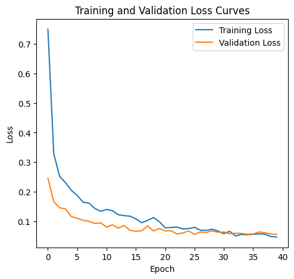

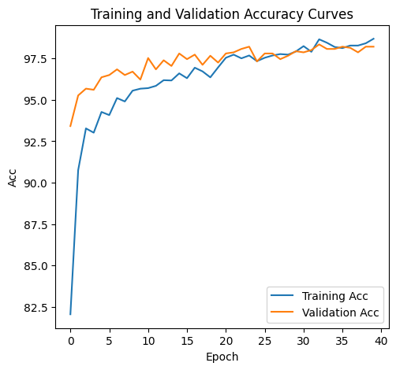

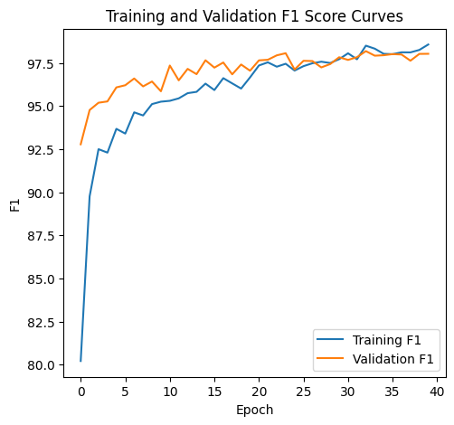

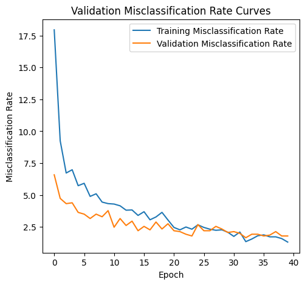

```python
Run()
```

## Testing

```python
def testing(model, test_loader, device):
    model.eval()
    all_ids = []
    all_preds = []

    with torch.no_grad():
        for ID, images in test_loader:
            images = images.to(device=device, dtype=torch.float)
            logits = model(images)
            preds = torch.argmax(logits, dim=1)
            all_ids.extend(ID)
            all_preds.extend(preds.cpu().numpy())

    return all_ids, all_preds
```

```python
seed_everything(config.seed)
device = config.device

test_data = pd.read_csv(os.path.join(config.root, 'test.csv'), header=None)
test_dataset = HandwrittenDigits(test_data, mode = "test")
test_loader = torch.utils.data.DataLoader(test_dataset, batch_size=config.batch_size, shuffle=False)  # 測試結果通常需要對應原始資料順序（如 ID 對 label）

model =  SimpleNN(input_dim=256, output_dim=10)
model.to(device)
best_ckpt = torch.load("checkpoint.pth", map_location=device, weights_only=False)
model.load_state_dict(best_ckpt["model"])

ids, preds = testing(model, test_loader, device)
```

```python
# Get predictions
ids, preds = testing(model, test_loader, device)

# Create DataFrame
results_df = pd.DataFrame({
    'ID': ids,
    'Class': preds
})

# # Save the DataFrame to a CSV file
# results_df.to_csv('test.digit.csv', index=False)
```

## 結果

```python
answer_df = pd.read_csv("/Users/tintsao/Desktop/交大統研所/碩一上/深度學習/DL_hw/Hw1/Answer/test_ans_hw1.csv", header = None)
# answer_df
answer_df.columns = ["ID", "real_label"]
comparison_df = pd.merge(results_df, answer_df, on="ID")
print(comparison_df.head(5))

# 準確率
acc = accuracy_score(comparison_df["real_label"], comparison_df["Class"])
print(f"\nAccuracy: {acc*100:.2f}%")
```

```
   ID  Class  real_label
0  B1      9           9
1  B2      6           6
2  B3      3           3
3  B4      6           6
4  B5      6           6

Accuracy: 94.87%
```